# Final Project - Predicting Baseball Players’ Offensive Capabilities

STAT 301-3

Albert Kim, Jordi Parry, Zachary Kornbluth

## Introduction

With the vastly available data sources today, data science and analytics are gaining traction throughout multiple fields and studies, leading to new technological applications unseen before in any aspect of human history. One such example is in one of America’s favorite sports– baseball– where data science is used to guide processes such as custom training regiment constructions and rookie scouting.

This dataset consists of batting statistics of MLB player seasons of players with at least 100 plate appearances during the 2019 and 2020 seasons. It is important to note that observations may not encapsulate all baseball players part of a MLB team as observations were only recorded for players with at least 100 plate appearances.

## Overview of the Report

In the following sections, a data science pipeline will be constructed using the MLB player data. First, an exploratory data analysis will be conducted prior to model building in order to note interesting relationships and potential issues within the data. This will be done by skimming through the data set to denote basic aspects of the dataset such as number of predictors, observations, and missingness followed by data visualizations of predictor-response variable relationships.

After, a recipe will be constructed, preprocessing the data based on findings from the exploratory data analysis. A resampling object, notable repeated v-fold cross validation, will be instantiated for model training in order to ensure model generalizability and to test different hyperparameter combinations for the models.

From here, the models and their relevant workflows will be defined, tuned, and analyzed. Specifically, the following models will be tested: random forest, boosted tree, support vector machine (radial basis), neural network, and ensemble model (from random forest, boosted tree, and support vector machine). The best two models will then be selected and fitted onto the entire training data set where final RMSE scores will be derived from the testing dataset.

## Data Splitting

Prior to conducting any analyses, the dataset will be intialized and partitioned into designated training and testing data. The training dataset will be used for the subsequent analyses whereas the testing data will be used at the end to evaluate the efficacy of the final, chosen model.

```r
# read in data set and remove name and derived statistics
mlb_data <- read.table('data/mlb_data.txt', header = TRUE, sep = " ") %>%
  subset(select = -c(name, year, b_total_pa, xops, xba, xslg, xwoba, xobp, xiso))

# set seed for reproducing data split
set.seed(123)

# initial split of training-testing set.
mlb_split <- initial_split(mlb_data, 0.75, strata = ops)
train_mlb <- training(mlb_split)
test_mlb <- testing(mlb_split)

# save training and testing sets
write_csv(train_mlb, "data/training_data_mlb.csv")
write_csv(test_mlb, "data/testing_data_mlb.csv")
```

In addition, a resampling object is created from the training data. Specifically, a 3-repeat-5 fold cross validation set is defined. This is important during the model training process as it prevents overfitting and encourages generalizability by defining different combinations of training data to build models from. The code for this is shown below:

```r
# set seed for reproducibility
set.seed(2025)

# define validation
mlb_folds <- vfold_cv(data = mlb_train, v = 5, repeats = 3, strata = ops)
```

## Exploratory Data Analysis

In this section, the exploratory data analysis will be conducted on the training data set.

Below is a basic skim of the constructed training data set:

```r
# load data
training_data_mlb <- read_csv('data/training_data_mlb.csv')

# skim training data
skim_without_charts(training_data_mlb)
```

Data summary

| Name | training_data_mlb |
| --- | --- |
| Number of rows | 569 |
| Number of columns | 15 |
| _______________________ |  |
| Column type frequency: |  |
| numeric | 15 |
| ________________________ |  |
| Group variables | None |

**Variable type: numeric**

| skim_variable | n_missing | complete_rate | mean | sd | p0 | p25 | p50 | p75 | p100 |
| --- | --- | --- | --- | --- | --- | --- | --- | --- | --- |
| player_age | 0 | 1 | 28.41 | 3.72 | 20.0 | 26.0 | 28.0 | 31.0 | 40.0 |
| b_k_pct | 0 | 1 | 23.12 | 6.41 | 6.4 | 18.5 | 22.9 | 27.3 | 43.9 |
| b_bb_pct | 0 | 1 | 8.80 | 3.49 | 1.4 | 6.2 | 8.4 | 11.0 | 20.1 |
| ops | 0 | 1 | 74.85 | 11.58 | 32.2 | 67.0 | 74.3 | 82.8 | 110.2 |
| exit_velocity_avg | 0 | 1 | 88.62 | 2.28 | 80.7 | 87.2 | 88.8 | 90.1 | 96.0 |
| launch_angle_avg | 0 | 1 | 12.68 | 5.00 | -7.9 | 9.4 | 12.8 | 16.0 | 26.8 |
| barrel_batted_rate | 0 | 1 | 7.54 | 4.29 | 0.0 | 4.3 | 7.0 | 10.4 | 25.6 |
| solidcontact_pct | 0 | 1 | 5.96 | 2.36 | 0.0 | 4.4 | 6.0 | 7.5 | 14.5 |
| hard_hit_pct | 0 | 1 | 37.37 | 8.11 | 7.3 | 32.1 | 38.1 | 42.9 | 58.4 |
| z_swing_pct | 0 | 1 | 66.95 | 6.23 | 47.5 | 62.7 | 67.1 | 71.1 | 82.8 |
| z_swing_miss_pct | 0 | 1 | 17.95 | 5.67 | 3.1 | 14.3 | 17.6 | 21.6 | 35.6 |
| oz_swing_pct | 0 | 1 | 28.34 | 6.69 | 11.7 | 23.9 | 27.7 | 32.6 | 51.3 |
| oz_swing_miss_pct | 0 | 1 | 43.50 | 10.30 | 12.6 | 36.4 | 43.3 | 50.0 | 76.9 |
| oz_contact_pct | 0 | 1 | 56.50 | 10.30 | 23.1 | 50.0 | 56.7 | 63.6 | 87.4 |
| iz_contact_pct | 0 | 1 | 82.05 | 5.67 | 64.4 | 78.4 | 82.4 | 85.7 | 96.9 |

From these results, there are 15 numeric variables contained in the training data set with 14 predictors and 1 response variable: ops (on-base plus slugging). As we are attempting to predict a quantitative variable, the machine learning problem is regressive by nature.

Interestingly enough, there are no corresponding missing data for any of the predictors which indicates that missingness is not a problem to tackle during the recipe construction process of model building.

#### Findings

In the following section, data visualization will be used in order to explore relationships between predictors and the response variable ops.

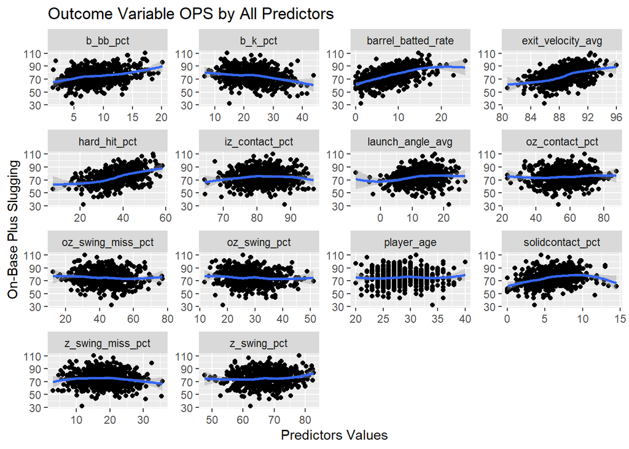

```r
# plot all variables by ops, note any irregularities
training_data_mlb %>%
  gather(-c(ops), key = "var", value = "value") %>%
  ggplot(aes(x = value, y = ops)) + geom_point() +
    geom_smooth() +
    facet_wrap(~var, scales = "free") +
    labs(x = "Predictors Values", y = "On-Base Plus Slugging", title = "Outcome Variable OPS by All Predictors")
```

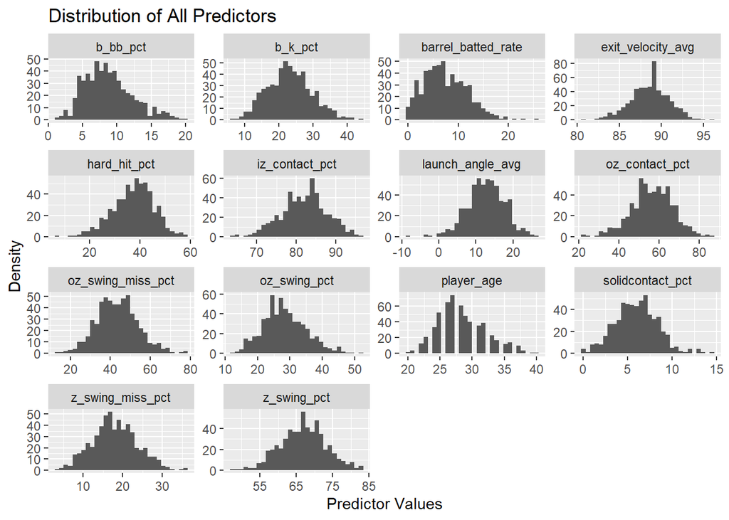

```r
# get individual distributions of all predictors
training_data_mlb %>%
  gather(-c(ops), key = "var", value = "value") %>%
  ggplot(aes(x = value)) +
    geom_histogram() +
    facet_wrap(~var, scales = "free") +
    labs(x = "Predictor Values", y = "Density", title = "Distribution of All Predictors")
```

Above include two plots that summarize outcome-predictor relationships and predictor distributions respectively.

From the first graph, it is evident that some predictors notably b_bb_pct, barrel_batted_rate, exit_velocity_avg, and hard_hit_pct have relatively strong associations with the outcome variable. As all of these measures capture different aspects of a player’s offensive skill, it is not surprising that they are associated with the OPS outcome variable considering the OPS score is considered as an overall measure of offensive capabilities. On the other hand, other variables such as player age did not have any noticeably associations with the response variable as hypothesized.

On the second graph, the distributions of predictor variables were explored in order to see if any preprocessing would be required prior to the model building process. From above, most predictors appear to be relatively symmetric with the exception of b_bb_pct, barrel_batted_rate, and oz_contact_pct. Although not very extreme, it may be useful to apply log transformations or other methods such as Box-Cox or Yeo-Johnson transformations to account for this skewness.

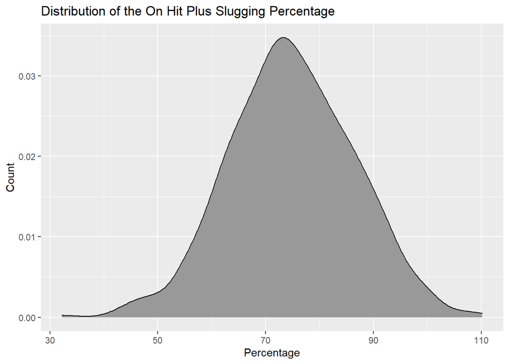

```r
# see distribution of the response variable
ggplot(training_data_mlb, aes(x = ops)) +
  geom_density(fill = "grey60") +
  labs(title = "Distribution of the On Hit Plus Slugging Percentage",
       x = "Percentage",
       y = "Count")
```

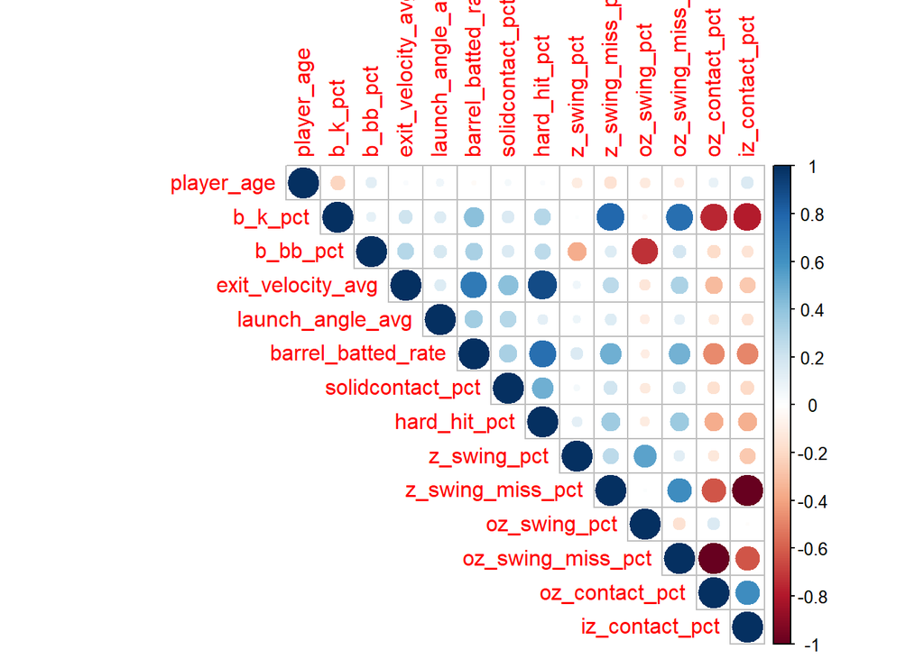

```r
# check correlations between predictors to see if removal is necessary for any
corrplot::corrplot(cor(training_data_mlb %>% select(-c(ops))), method = "circle", type = "upper")
```

The plots above summarize the distribution of the response variable as well as correlations between predictors.

The above density plot displays the general distribution of the response variable, ops. The distribution appears to be fairly symmetrical with a center approximately around 74 where the bulk of data is contained within 60 and 90 percent. Without any extreme skewness or other problematic patterns, this plot suggests that additional preprocessing such as log transformations may not be necessary for the response variable moving forward with the model building process.

Addressing the correlation plot, there appears to be a couple of strong associations between pairs of certain predictors. In particular, iz_contact_pct/z_swing_miss_pct and oz_contact_pct/oz_swing_miss_pct have near one-to-one correlations, which suggest that there is redundant information in these pairs. As such, oz_swing_miss_pct and z_swing_miss_pct will be removed from the data in order to correct potential collinearity issues during the model building process.

## Feature Extraction

Now that the exploratory data analysis has been conducted, a recipe will be constructed with feature extraction to address concerns brought up from the EDA.

To begin, the target variable `ops` and all predictors were added onto the recipe. As noted in the EDA, there are a few variables that are highly correlated with one another. In order to preemptively address potential problems with collinearity, the correlated variables `z_swing_miss_pct` and `oz_swing_miss_pct` are removed from the dataset. In addition, given the skewness noticed in `b_bb_pct`, `barrel_batted_rate`, and `oz_contact_pct`, these variables are log transformed to ensure more symmetric distributions. An offset of `1e-16` was included to handle values of 0 in variables, which was noted in `barrel_batted_rate`. Finally, all predictors were normalized to account for differences in predictor scale.

The code for recipe construction is shown below:

```r
# recipe construction
mlb_recipe <- recipe(ops ~ ., data = train_mlb) %>%
  step_rm(z_swing_miss_pct, oz_swing_miss_pct) %>%
  step_log(b_bb_pct, barrel_batted_rate, oz_contact_pct, offset = 1e-16) %>%
  step_normalize(all_predictors())
```

## Model Fitting

With the recipe now constructed, models were constructed and fit onto the resampled data, where hyperparameter performance was evaluated. The relevant code for this process can be found in the tuning_scripts folder. The following table summarizes the performance of all models tested:

| Model | Hyperparameters | RMSE |
| --- | --- | --- |
| Boosted Tree | mtry = 4, min_n = 40 | 8.949840 |
| Random Forest | mtry = 10, min_n = 21 | 8,431625 |
| Neural Network | hidden_units = 1, penalty = 1 | 8.254791 |
| SVM RBF | cost = 32, rbf_sigma = 0.003162278 | 8.731447 |

Of these four models, the neural network performed the best with a RMSE score of 8.254791 followed by random forest and support vector machine. This is not surpring as neural networks are state of the art models for many data science problems. As such, the neural network model will be chosen for evaluation on the testing dataset.

Additionally, an ensemble model was constructed using boosted tree, random forest, and support vector machines as the components. The neural network model was not chosen due to issues in R that prevented the addition of the neural network onto the ensemble model. The results after blending is shown below:

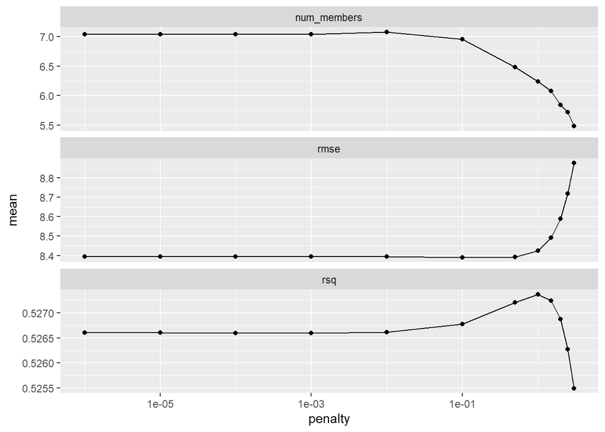

```r
# load ensemble model blended file
load(file = "tuning_scripts/mlb_model_stacked" )

# plot tuning graphs
autoplot(mlb_model_stacked)
```

With a RMSE value of 8.394 at the best blended combination, the ensemble model outperformed each of its candidate models. As such, it will also be chosen for evaluation on the testing data set.

## Model Evaluation and Conclusion

Now that the best two models have been selected for final evaluation, in this section, the neural network and ensemble model will be evaluated on the testing data set.

Below contains a script that fits and evaluates the ensemble model as well as its member models:

```r
# set seed for reproducible results
set.seed(9876)

# load testing data
test_mlb <- read_csv("data/testing_data_mlb.csv")

# fit to ensemble to entire training set
mlb_model_stacked_fitted <- mlb_model_stacked %>%
  fit_members()

# get predictions based on member models
member_preds <- test_mlb %>%
  select(ops) %>%
  bind_cols(predict(mlb_model_stacked_fitted, test_mlb, members = TRUE))

# store results
results_ensemble <- map_dfr(member_preds, rmse, truth = ops, data = member_preds) %>%
  mutate(member = colnames(member_preds))
```

```r
# print results
print(results_ensemble)
```

```
## # A tibble: 9 x 4
##   .metric .estimator .estimate member
##   <chr>   <chr>          <dbl> <chr>
## 1 rmse    standard        0    ops
## 2 rmse    standard        6.06 .pred
## 3 rmse    standard        6.63 rf_tuned_1_25
## 4 rmse    standard       10.8  svm_res_1_15
## 5 rmse    standard        8.33 svm_res_1_20
## 6 rmse    standard        5.57 bt_tuned_1_112
## 7 rmse    standard        6.33 bt_tuned_1_122
## 8 rmse    standard        5.76 bt_tuned_1_119
## 9 rmse    standard        6.38 bt_tuned_1_124
```

Additionally, below contains a script that finalizes, fits, and evaluates the neural network:

```r
# load tuned nnet
load("tuning_scripts/nnet_tuned.rda")

#nnet model
nnet_model <- mlp(hidden_units = tune(),
                  penalty = tune()) %>%
  set_engine("nnet", trace = 0) %>%
  set_mode("regression")

# neural net workflow
nnet_workflow <- workflow() %>%
  add_model(nnet_model) %>%
  add_recipe(mlb_recipe)

# finalize workflow
nnet_workflow_final <- nnet_workflow %>%
  finalize_workflow(select_best(nnet_tuned, metric = "rmse"))

# fit onto training data
nnet_fitted <- fit(nnet_workflow_final, training_data_mlb)

# get predictions
predicted_values <- predict(nnet_fitted, new_data = test_mlb, type = "numeric") %>%
  bind_cols(test_mlb %>% select(ops)) %>%
  rmse(.pred, ops)

print(predicted_values)
```

```
## # A tibble: 1 x 3
##   .metric .estimator .estimate
##   <chr>   <chr>          <dbl>
## 1 rmse    standard        8.18
```

–

In conclusion, the ensemble model comprising of member functions from random forest, boosted tree, and support vector machine models had the strongest predictive power with the testing RMSE score of 6.055356. As such, this project is deemed a success as a model was created that can reliably predict a player’s on base plus slugging percentage, therefore demonstrating the potential applications of data science into sports with the greater availability of data during the modern age.

In order to improve results, additional models could have been tested, including MARS and elastic net models. Creating an ensemble model from a greater selection of candidate models may also improve model performance compared to the results obtained above. Additionally, other steps in preprocessing could have been implemented such as Box-Cox transformations, which may yield better results. Finally, additional data to train on from perhaps previous years may have been helpful for further improving the model training processes.